# Web Scraping: Setup Instructions

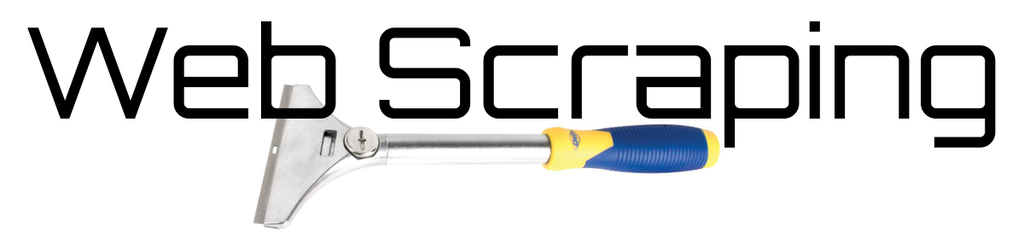

To ensure that everything runs smoothly on the day, please work your way through these setup instructions and make sure that you have everything in place before we start.

## Browser

We’ll be using Chrome. Although you should be fine with any browser, it’ll be easier to follow along if you have Chrome.

### Browser Plugins

Please install the following browser plugins:

- [SelectorGadget](https://chrome.google.com/webstore/detail/selectorgadget/mhjhnkcfbdhnjickkkdbjoemdmbfginb)
- [Toggle JavaScript](https://chrome.google.com/webstore/detail/toggle-javascript/cidlcjdalomndpeagkjpnefhljffbnlo)

## R

You’ll need to have a recent version of R. Version 4.0.2 would be preferable.

### RStudio

We’ll be working in RStudio. Do yourself a favour and [grab a recent version](https://rstudio.com/products/rstudio/download/) of this too.

### R Packages

Please install the following packages:

- tidyverse
- rvest
- robotstxt
- RSelenium
- splashr
- urltools
- RSQLite
- webshot
- lubridate
- janitor
- scico
- patchwork
- memoise

## Docker

### Windows

#### Docker Desktop

If you are on a recent version of Windows, then follow [these instructions](https://docs.docker.com/docker-for-windows/install/) to install Docker Desktop. When the installer is finished you should see a small whale icon in the notifications area.

#### Docker Toolbox

Alternatively, if you’re on an older version of Windows, then follow [these instructions](https://docs.docker.com/toolbox/toolbox_install_windows/) to install Docker Toolbox.

Docker Toolbox is also a better choice if you need to run VirtualBox on your machine, because VirtualBox is not compatible with Docker Desktop, which requires Hyper-V.

### Linux

Follow [these instructions](https://runnable.com/docker/install-docker-on-linux) to install Docker. Alternatively, if you are on Ubuntu or Debian, then you can try [this recipe](https://gist.github.com/datawookie/9f29795059e6bccf9892bc85ed285337).

To make things easier on yourself, add your user to the `docker` group.

### Mac

Follow [these instructions](https://docs.docker.com/docker-for-mac/install/) to install Docker Desktop.

Once you’ve installed Docker, test it by launching the “Hello World” image.

### Windows

#### Docker Desktop

Follow [these instructions](https://docs.docker.com/docker-for-windows/) to get started with Docker Desktop.

[figure not shown]

1. Check the notifications area for the icon, which shows that Docker is running.
2. Launch a command shell and then run the following:

```bash
docker run hello-world
```

#### Docker Toolbox

The instructions for testing Docker Toolbox can be found towards the bottom of the installation instructions.

1. Launch the Docker Quickstart Terminal (this may take a short while to start).
2. When you see a prompt in the terminal, run the following:

```bash
docker run hello-world
```

### Linux

In a terminal window run the following:

```bash
# If your user is in the docker group
docker run hello-world
# If your user is not in the docker group
sudo docker run hello-world
```

### Mac

Follow [these instructions](https://docs.docker.com/docker-for-mac/) to get started with Docker Desktop.

In a terminal window run the following:

```bash
docker run hello-world
```

If you see output like this, then you’ve been successful.

```
Hello from Docker!
This message shows that your installation appears to be working correctly.

To generate this message, Docker took the following steps:
 1. The Docker client contacted the Docker daemon.
 2. The Docker daemon pulled the "hello-world" image from the Docker Hub.
    (amd64)
 3. The Docker daemon created a new container from that image which runs the
    executable that produces the output you are currently reading.
 4. The Docker daemon streamed that output to the Docker client, which sent it
    to your terminal.

To try something more ambitious, you can run an Ubuntu container with:
 $ docker run -it ubuntu bash

Share images, automate workflows, and more with a free Docker ID:
 https://hub.docker.com/

For more examples and ideas, visit:
 https://docs.docker.com/get-started/
```

*Please* ensure that you have a working Docker setup *before* the workshop. We will not have time to debug this on the day. If you need help, then please ask in advance.

## Selenium

We’ll be using Docker to launch Selenium. The Selenium image is pretty big, so please download and test it now!

```
docker run selenium/standalone-chrome-debug:3.141
```

## Remote Desktop Client

Install [VNC Viewer](https://www.realvnc.com/en/connect/download/viewer/) so that you can connect to your Selenium Docker container. Just make sure that it runs. We’ll configure it during the workshop.

One important piece of information that we’ll need when connecting to the Selenium container will be its IP address.

### Windows

#### Docker Desktop

The Docker IP address is 127.0.0.1.

#### Docker Toolbox

In the terminal run the following:

```bash
docker-machine ip
```

The result should be 192.168.99.100.

### Linux

The Docker IP address is 127.0.0.1.

### Mac

The Docker IP address is 127.0.0.1.